# EDGE: The NFL Play Recommendation System

The goal for this project is to create a Recommender System that can determine the best play call given specific situations to maximize a teams chance of adding points (EPA), while also being user-friendly.

First things first What Is EPA?

Expected Points Added (EPA) is a statistic used to gauge the value of a play and is the main statistic that the NFL uses these days. Expected Points (EP) is used to gauge the states of a play. Expected Points takes into account the Down, how many yards until First down (yards to go), how much time left in the half, and field position. This equation is based off of every single play in NFL history and is recalculated after every week.

#### Data Clean Up

To give our model as many scenarios as possible, data of every snap, from every game, for the last decade of games were aggregated. Together the data begins with Bears vs Packers in 2019 and ends with Seattle vs ST Louis Rams.

```python
YEARS = [2019,2018,2017,2016,2015,2014,2013,2012,2011]
data = pd.DataFrame()

for i in YEARS:
    i_data = pd.read_csv('https://github.com/guga31bb/nflfastR-data/blob/master/data/' \
                         'play_by_play_' + str(i) + '.csv.gz?raw=True',
                         compression='gzip', low_memory=False)

    data = data.append(i_data, sort=True)
data.reset_index(drop=True, inplace=True)
```

|  | play_id | game_id | home_team | away_team | posteam | posteam_type | defteam | side_of_field | yardline_100 | game_date | ... | penalty_player_id | penalty_player_name | penalty_yards | replay_or_challenge | replay_or_challenge_result | penalty_type | defensive_two_point_attempt | defensive_two_point_conv | defensive_extra_point_attempt | defensive_extra_point_conv |
| --- | --- | --- | --- | --- | --- | --- | --- | --- | --- | --- | --- | --- | --- | --- | --- | --- | --- | --- | --- | --- | --- |
| 0 | 35 | 2019090500 | CHI | GB | GB | away | CHI | CHI | 35.0 | 2019-09-05 | ... | NaN | NaN | NaN | 0 | NaN | NaN | 0.0 | 0.0 | 0.0 | 0.0 |
| 1 | 50 | 2019090500 | CHI | GB | GB | away | CHI | GB | 75.0 | 2019-09-05 | ... | NaN | NaN | NaN | 0 | NaN | NaN | 0.0 | 0.0 | 0.0 | 0.0 |
| 2 | 71 | 2019090500 | CHI | GB | GB | away | CHI | GB | 75.0 | 2019-09-05 | ... | NaN | NaN | NaN | 0 | NaN | NaN | 0.0 | 0.0 | 0.0 | 0.0 |
| 3 | 95 | 2019090500 | CHI | GB | GB | away | CHI | GB | 75.0 | 2019-09-05 | ... | NaN | NaN | NaN | 0 | NaN | NaN | 0.0 | 0.0 | 0.0 | 0.0 |
| 4 | 125 | 2019090500 | CHI | GB | GB | away | CHI | GB | 85.0 | 2019-09-05 | ... | NaN | NaN | NaN | 0 | NaN | NaN | 0.0 | 0.0 | 0.0 | 0.0 |
| ... | ... | ... | ... | ... | ... | ... | ... | ... | ... | ... | ... | ... | ... | ... | ... | ... | ... | ... | ... | ... | ... |
| 44746 | 4022 | 2011010215 | SEA | STL | STL | away | SEA | STL | 59.0 | 2011-01-02 | ... | NaN | NaN | NaN | 0 | NaN | NaN | 0.0 | 0.0 | 0.0 | 0.0 |
| 44747 | 4041 | 2011010215 | SEA | STL | STL | away | SEA | STL | 63.0 | 2011-01-02 | ... | NaN | NaN | NaN | 0 | NaN | NaN | 0.0 | 0.0 | 0.0 | 0.0 |
| 44748 | 4071 | 2011010215 | SEA | STL | STL | away | SEA | STL | 71.0 | 2011-01-02 | ... | NaN | NaN | NaN | 0 | NaN | NaN | 0.0 | 0.0 | 0.0 | 0.0 |
| 44749 | 4096 | 2011010215 | SEA | STL | SEA | home | STL | STL | 43.0 | 2011-01-02 | ... | NaN | NaN | NaN | 0 | NaN | NaN | 0.0 | 0.0 | 0.0 | 0.0 |
| 44750 | 4117 | 2011010215 | SEA | STL | NaN | NaN | NaN | STL | NaN | 2011-01-02 | ... | NaN | NaN | NaN | 0 | NaN | NaN | NaN | NaN | NaN | NaN |

453797 rows × 256 columns

#### There are a lot of dead plays in football such as penalties and time outs, for the scope of this project they were removed.

```python
data['desc'].loc[data['play_type'] == 'no_play']
```

```
5        (13:01) (Shotgun) T.Cohen FUMBLES (Aborted) at...
30                             Timeout #1 by CHI at 01:50.
31       (1:50) (Shotgun) M.Trubisky pass incomplete sh...
61       (4:19) (Shotgun) T.Cohen left tackle pushed ob...
73       (:55) (Shotgun) PENALTY on GB-A.Rodgers, False...
                               ...
44736    (2:00) M.Lynch right tackle to STL 7 for 4 yar...
44738                          Timeout #2 by STL at 01:47.
44740                          Timeout #3 by STL at 01:41.
44743    (1:33) (Shotgun) PENALTY on SEA-C.Clemons, Def...
44745    (1:23) (Shotgun) PENALTY on STL-S.Bradford, De...
Name: desc, Length: 42666, dtype: object
```

Here general data clean up is completed, that includes creating our success column which is a binary column of good/bad EPA. The criterion for success was determined as any play greater than 0 EPA was deemed a success and negative play was unsuccessful. A new feature engineereed was creating the different concepts from previous columns that specify where the ball ended up going. (The Data courtesy of NFLScrapR)

The different concepts are as follows: Runs (left or right) off of different Offensive Lineman. Tight end, Tackles and Guards. Passes (left or right) based on distance. Short passes are anything 15 yards and less, while deep passes are 15 yards and longer.

## Decision Tree

A regression decision tree was at first to predict a given EPA based on situational football. Decision Trees are supervised machine learning model that use past data to predict new data. They break down the data by making a decision based on rules or "asking questions of our model" used to predicts a target. In our case its EPA on a given play.

```python
# Decision Tree
from sklearn.tree import DecisionTreeRegressor
regressor = DecisionTreeRegressor()
regressor.fit(matrix_train, target_train)
```

[output not shown]

After breaking down the model it has to be validated to see what the scores are and determine the accuracy of it. This is done by splitting the data before hand into training and testing features, once the model is run on the training features, we use a predict function and compare those answers to the actual (test) results. In this case our predicted values seem slightly off from the actual but we can run tests to specifically find out by how much.

```python
from sklearn import metrics
print('Mean Absolute Error:', round(metrics.mean_absolute_error(play_target_test_m2, Y_pred2),2))
print('Mean Squared Error:', round(metrics.mean_squared_error(play_target_test_m2, Y_pred2),2))
print('Root Mean Squared Error:', np.sqrt(round(metrics.mean_squared_error(play_target_test_m2, Y_pred2),2)))
```

```
Mean Absolute Error: 0.61
Mean Squared Error: 1.43
Root Mean Squared Error: 1.1958260743101399
```

Mean Absolute Error is the most significant value in this case and it shows the results of our predicted values vs the actual values. So on average our model was off by 0.61 EPA. Ideally the perfect model is closer to 0 but we will implement a random forest regressor to get a better prediction.

Mean squared error and RMSE are more useful when worried about outliers but for the scope of this project that does not concern us.

### Random Forest

With that high of error, we can try to find ways to fine tune and improve the model. The most basic way is to run a random forest module. Random Forests are an ensemble of decision trees used to find the best accuracy of the model, called "bagging".

```python
from sklearn.ensemble import RandomForestRegressor

rfregressor = RandomForestRegressor(n_estimators=20, random_state=0)
rfregressor.fit(matrix_train, target_train)
y_pred = rfregressor.predict(matrix_test)
```

[output not shown]

Random forest yields an improvement in all 3 values, our model now is off by less than .5 EPA points and this seems more acceptable to predict plays with.

# Play Recommender System

To create the recommendation system, several random forest models were aggregated based on the inputted situations and modifying each iteration for success =1 or success = 0. Each concept was iterated through to find the EPA that would be produced given the situation provided by the user. The difference between the successful and unsuccessful plays were aggregated into a dataframe to give a simple view of the all the options and what the outcomes could potentially be.

```
Enter yardline_100 : 3
Enter game_seconds_remaining : 30
Enter qtr : 4
Enter down : 2
Enter ydstogo : 3
Enter posteam_timeouts_remaining : 1
Enter score_differential : -1
```

|  | Concepts | FinalEPA |
| --- | --- | --- |
| 5 | short middle pass | 1.57 |
| 3 | short left pass | 1.51 |
| 0 | Deep left pass | 1.36 |
| 2 | Deep middle pass | 1.21 |
| 4 | short right pass | 0.82 |
| 6 | run left guard | 0.78 |
| 7 | run left tackle | 0.77 |
| 8 | run left end | 0.61 |
| 10 | run right tackle | 0.58 |
| 9 | run right guard | 0.41 |
| 1 | Deep right pass | -0.32 |
| 11 | run right end | -0.68 |

### Visualizing the table

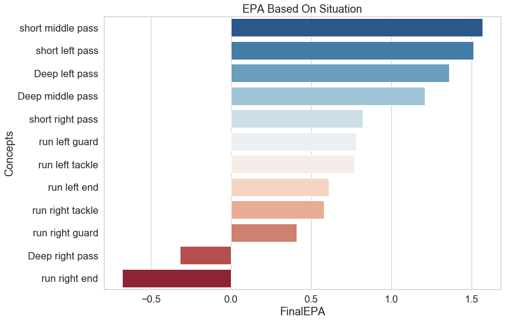

```python
def graph(epa, concept, df):
    a4_dims = (11.7, 8.27)
    fig, ax = pyplot.subplots(figsize=a4_dims)
    #df_c = df_c.sort_values('Count')
    sns.barplot(x=epa, y=concept, data=df, palette='RdBu_r', edgecolor = 'w')#,dodge=False)
    ax.set_xlabel('FinalEPA')
    ax.set_title('EPA Based On Situation')
    sns.set(style="whitegrid", font_scale=1.5)

graph('FinalEPA', 'Concepts', ScoringChance)
```

### In Super Bowl 49 the Seattle Seahawks were on the Patriots 1 yardline with 2nd down and goal to go. Down 4 points, with only 26 seconds left and 1 timeout, whats the call? Lets see what the model would do.

[figure not shown]

```
Enter yardline_100 : 1
Enter game_seconds_remaining : 26
Enter qtr : 4
Enter down : 2
Enter ydstogo : 1
Enter posteam_timeouts_remaining : 1
Enter score_differential : -4
```

|  | Concepts | FinalEPA |
| --- | --- | --- |
| 2 | Deep middle pass | 1.52 |
| 0 | Deep left pass | 1.47 |
| 3 | short left pass | 1.18 |
| 5 | short middle pass | 1.16 |
| 6 | run left guard | 1.06 |
| 9 | run right guard | 1.02 |
| 8 | run left end | 1.01 |
| 10 | run right tackle | 0.98 |
| 7 | run left tackle | 0.97 |
| 4 | short right pass | 0.79 |
| 1 | Deep right pass | -0.29 |
| 11 | run right end | -0.59 |

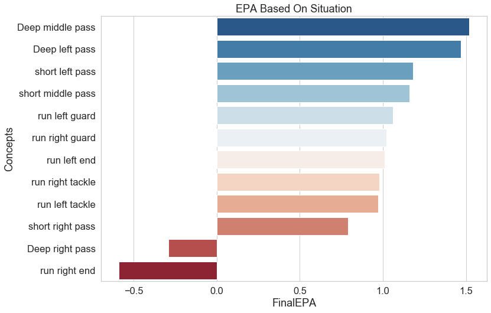

Will add the rest of the code in the near future